# Trends in Maryland Crime Rates

Bilsay Varcin

April 13, 2020

## Maryland crime data

Crime rates vary across space and time. The reasons crimes are committed in some places but not others can be difficult to detect because of complex socio-economic factors, but policymakers still need to understand how crime rates are changing from place to place and from time to time to inform their policies.

Many government statistics, such as crime rates, come from nested datasets. Most US States are divided into counties (Alaska has “burrows,” and Louisiana has “parishes”), and counties and county-level governments can vary within the same state. For example, one county might have a high population density and be urban, whereas a second county might have a low population density and be rural.

In this project we will use a form of regression called hierarchical modeling to capture and explore crime statistics collected by the State of Maryland to see if there is a linear trend in violent crime across the state between 1975 and 2016. These data come from the Maryland Statistical Analysis Center.

This figure shows population per county across the state of Maryland in 2016. By the end of the project, we will create a similar figure for each county’s crime rate.

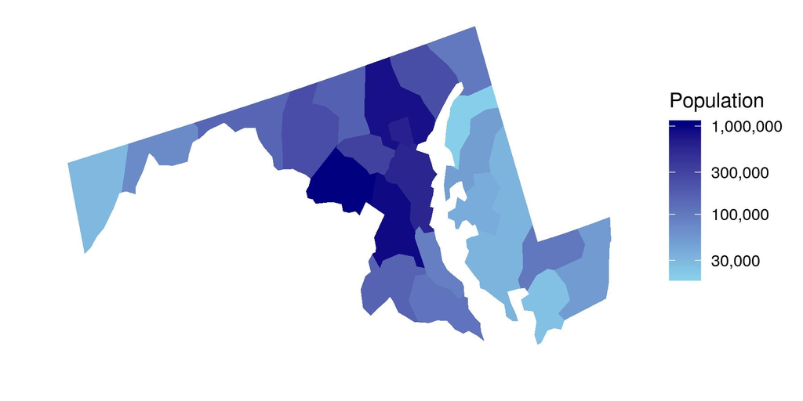

Before running a regression analysis, we often need to tidy data. Everyday tidying tasks include renaming and reformatting columns.

## Raw data and trend lines

Before running a regression or building a model, it’s a good idea to explore the data. Exploratory data analysis (EDA) will help us see outliers, possible data errors, or trends. There is no single coding technique for EDA, but plotting the data is a great first step. A picture (or well-designed figure) can be worth a thousand summary statistics!

Let’s plot the crime rate over time for each county and add a linear trend line.

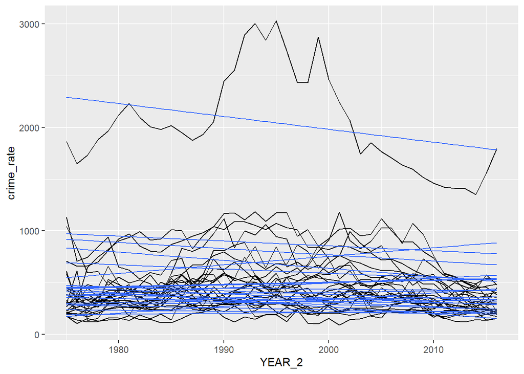

## Build a LMER

Now we can build a hierarchical model, also known as a linear mixed-effects regression model, using lmer(). lmer() uses syntax similar to lm(), but it requires a random-effect argument. For example, y predicted by fixed-effect slope, x , and random-effect intercept, group , would be y ~ x + (1|group). x can also be included as a random-effect slope: y ~ x + (x|group). Hierarchical and Mixed Effect Models covers these models in greater detail.

We are going to see if a linear trend through time can predict violent crime rates. We will estimate the crime trend for the entire state (a fixed-effect slope) and trends for each county (random-effect slopes). By treating each county as a random-effect, we assume the trend for each county comes from a state-wide distribution.

We’ll use the lmerTest package because it adds p-values for fixed-effect coefficients to lmer() models, something the lme4 package does not include for reasons listed on the project’s FAQ page.

## Model outputs

Let’s examine the model’s output. lmer() outputs are similar to lm() outputs, but lmer() outputs include extra information about both fixed- and random-effects. The Hierarchical and Mixed-effects Models course provides more information on lmer() summary outputs.

The fixed-effect trend for YEAR_3 is not significantly different from zero, but what do the estimates look like for different counties? We can access the regression coefficients using fixef() and ranef().

```
## Linear mixed model fit by REML. t-tests use Satterthwaite's method [
## lmerModLmerTest]
## Formula: crime_rate ~ YEAR_3 + (YEAR_3 | JURISDICTION)
##    Data: crime_use
##
## REML criterion at convergence: 13144.4
##
## Scaled residuals:
##     Min      1Q  Median      3Q     Max
## -4.4467 -0.4675 -0.0546  0.4328  6.5170
##
## Random effects:
##  Groups       Name        Variance  Std.Dev. Corr
##  JURISDICTION (Intercept) 183231.42 428.055
##               YEAR_3          17.94   4.236  -0.69
##  Residual                  23141.39 152.123
## Number of obs: 1008, groups:  JURISDICTION, 24
##
## Fixed effects:
##             Estimate Std. Error       df t value Pr(>|t|)
## (Intercept) 529.0308    87.8821  22.9668   6.020 3.89e-06 ***
## YEAR_3       -1.4246     0.9507  22.9853  -1.498    0.148
## ---
## Signif. codes:  0 '***' 0.001 '**' 0.01 '*' 0.05 '.' 0.1 ' ' 1
##
## Correlation of Fixed Effects:
##        (Intr)
## YEAR_3 -0.660
## convergence code: 0
## Model failed to converge with max|grad| = 0.0167762 (tol = 0.002, component 1)
```

```
## [1] **** Fixed-effects ****
```

```
##    YEAR_3
## -1.424551
```

```
## [1] **** Random-effects ****
```

```
##  [1]   6.38788013   4.81462314 -10.69338633  -3.94835788  -1.82530226
##  [6]   2.15643569   0.75049213   2.77906999   2.70974127  -2.19196232
## [11]  -1.42736199   2.19631991   0.25558711  -3.82371742   2.49308956
## [16]   0.03515831  -3.06303714  -0.78719434   0.55556573   0.14712656
## [21]  -1.77479609   2.34186466   7.09396163  -5.18180004
```

## Format model coefficients

We estimated the crime rate for the entire state as a fixed-effect - this is the average crime rate across all of Maryland. We also estimated the crime rate for each county as a random-effect. To get the specific random-effect slope estimated for each county, we need to calucalate the difference between the county crime rate and the state average crime rate. For example, Allegany County had a slope estimate of 6.4 and Maryland had a slope estimate of -1.4. Adding these together, we get an estimated slope of 5.0 (6.4 + -1.4 = 5.0) for Allegany County.

We can use R to calculate the slope estimate for each county by extracting the fixed-effect estimate and adding it to the random-effect estimates.

## Maryland map data

We now have the crime trend data ready, but we need to get map data for the plot.

Let’s use the usmap package to get map data for the US. usmap data are already data frames, whereas the older maps package requires some wrangling to use with ggplot2.

## Matching county names

To plot the data, we need to merge the crime data (supplied by the State of Maryland) and the map data (provided in the usmap package), but first, we need to make sure county names are the same in both datasets. In this case, we are lucky - there is only one small difference.

## Merging data frames

Finally, both data frames have the same county names. Now we can merge them!

| x | y | order | hole | piece | group | fips | abbr | full | county | YEAR_3 |
| --- | --- | --- | --- | --- | --- | --- | --- | --- | --- | --- |
| 1775008 | -387237.8 | 22297 | FALSE | 1 | 24001.1 | 24001 | MD | Maryland | Allegany County | 4.963329 |
| 1779953 | -357902.4 | 22298 | FALSE | 1 | 24001.1 | 24001 | MD | Maryland | Allegany County | 4.963329 |
| 1789820 | -355286.0 | 22299 | FALSE | 1 | 24001.1 | 24001 | MD | Maryland | Allegany County | 4.963329 |
| 1796777 | -353431.8 | 22300 | FALSE | 1 | 24001.1 | 24001 | MD | Maryland | Allegany County | 4.963329 |
| 1824941 | -345915.7 | 22301 | FALSE | 1 | 24001.1 | 24001 | MD | Maryland | Allegany County | 4.963329 |
| 1828029 | -345083.7 | 22302 | FALSE | 1 | 24001.1 | 24001 | MD | Maryland | Allegany County | 4.963329 |

## Mapping trends

Woohoo! We’re ready to plot!

After creating the plot, see if any patterns emerge.

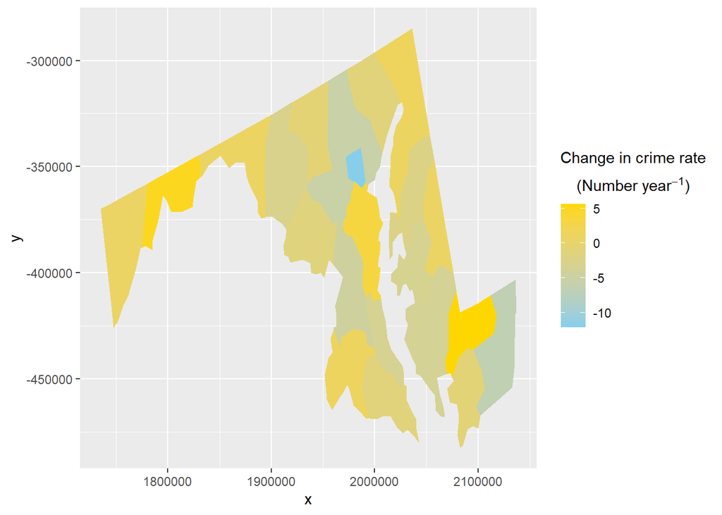

## Polish the map

Let’s clean up our plot so that we can present it policymakers.

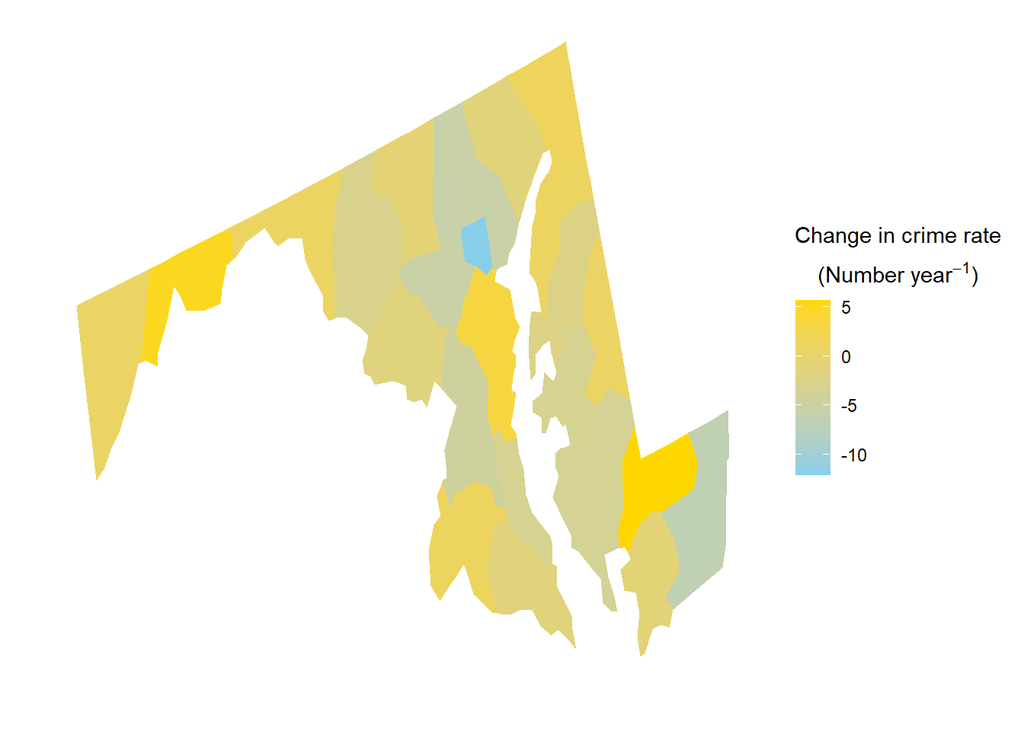

## Compare populations and crime rates

Statewide, we found no linear trend in crime rates across Maryland. But, trends in crime rates varied across the state. What should we tell a policymaker? We could say, Location is key. Crime increased in some locations but it also decreased in others.

Our analysis raises other question; comparing the population figure to the crime trends figure, we see that population might affect crime rate trends. Could other explanatory variables better explain a county’s crime rate? We could look for more explanatory variables in public data sources such those supplied by the State of Maryland, the US Federal Government at Data.gov, and the US Census Bureau.

Also, our figure suggests a nonlinear trend in some counties. We could either use a nonlinear model or only model the crime rate for the past 10 or 20 years. Nonlinear modeling in R with GAMS covers some nonlinear models. Additionally, we could build our own, more complicated regression using a language such as JAGS, covered in Bayesian Modeling with RJAGS. The last model approach would allow us to calculate credible intervals around the random-effects.

To finish up, we’ll quickly look to see if the population by county affects the crime rate.

```
## Linear mixed model fit by REML. t-tests use Satterthwaite's method [
## lmerModLmerTest]
## Formula: crime_rate ~ YEAR_3 + POPULATION + (YEAR_3 | JURISDICTION)
##    Data: crime_use
##
## REML criterion at convergence: 13160.1
##
## Scaled residuals:
##     Min      1Q  Median      3Q     Max
## -4.4481 -0.4659 -0.0545  0.4322  6.5152
##
## Random effects:
##  Groups       Name        Variance Std.Dev. Corr
##  JURISDICTION (Intercept) 184386.8 429.403
##               YEAR_3          18.1   4.255  -0.68
##  Residual                  23148.1 152.145
## Number of obs: 1008, groups:  JURISDICTION, 24
##
## Fixed effects:
##               Estimate Std. Error         df t value Pr(>|t|)
## (Intercept)  5.330e+02  9.181e+01  2.242e+01   5.805 7.16e-06 ***
## YEAR_3      -1.374e+00  1.010e+00  2.676e+01  -1.359    0.185
## POPULATION  -2.376e-05  1.547e-04  3.095e+01  -0.154    0.879
## ---
## Signif. codes:  0 '***' 0.001 '**' 0.01 '*' 0.05 '.' 0.1 ' ' 1
##
## Correlation of Fixed Effects:
##            (Intr) YEAR_3
## YEAR_3     -0.500
## POPULATION -0.279 -0.329
## fit warnings:
## Some predictor variables are on very different scales: consider rescaling
## convergence code: 0
## Model failed to converge with max|grad| = 0.0322298 (tol = 0.002, component 1)
```

```
## $JURISDICTION
##                        (Intercept)      YEAR_3
## Allegany County         -327.22428   6.3739881
## Anne Arundel County     -121.40622   4.8971058
## Baltimore City          1766.24968 -10.8194184
## Baltimore County         387.94632  -3.9168107
## Calvert County          -135.97576  -1.8479343
## Caroline County         -146.94314   2.1352133
## Carroll County          -298.73276   0.7440946
## Cecil County             -71.82014   2.7847022
## Charles County           -63.65423   2.7354540
## Dorchester County        150.61624  -2.2302161
## Frederick County         -69.15179  -1.4059349
## Garrett County          -339.06322   2.1589469
## Harford County          -180.46456   0.2671489
## Howard County           -124.70376  -3.7945019
## Kent County             -224.57417   2.4655454
## Montgomery County       -243.37547   0.1968961
## Prince George's County   449.83967  -2.9963116
## Queen Anne's County     -184.55545  -0.8248845
## Somerset County          -75.33004   0.5257197
## St. Mary's County       -155.13296   0.1308435
## Talbot County            -96.43543  -1.8212356
## Washington County       -238.92873   2.3275518
## Wicomico County           65.26742   7.1363125
## Worcester County         277.55277  -5.2222747
##
## with conditional variances for "JURISDICTION"
```